# HW 14

110078509

20220522

```r
df_question <- read.xlsx("security_questions.xlsx", sheet = 1)
df_data <- read.xlsx("security_questions.xlsx", sheet = 2)

sec_pca <- prcomp(df_data, scale. = T)
```

Question 1.

##### a. Show a single visualization with scree plot of data, scree plot of simulated noise (use average eigenvalues of ≥ 100 noise samples), and a horizontal line showing the eigenvalue = 1 cutoff.

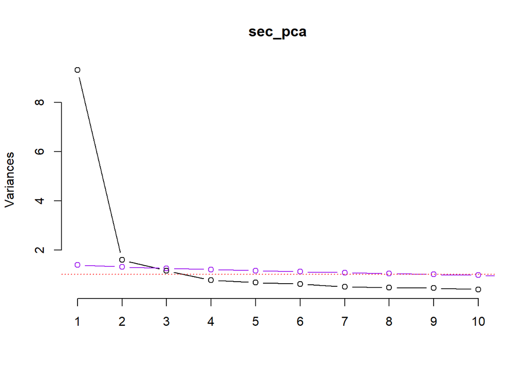

```r
##  1. Function to run a PCA on n ⨉ p dataframe of random values
set.seed(100)

sim_noise_ev <- function(n, p) {
noise <- data.frame(replicate(p, rnorm(n)))
eigen(cor(noise))$values
}

## 2. Repeat this k times
n <- dim(df_data)[1];
p <- dim(df_data)[2];

evalues_noise <- replicate(100, sim_noise_ev(n, p))

## 3. Average each of the noise eigenvalue
evalues_mean <- apply(evalues_noise, 1, mean)

## 4. ScreePlot
sec_pca <- prcomp(df_data, scale. = T)
screeplot(sec_pca, type="lines")
lines(evalues_mean, type="b", col = "purple")
abline(h=1, lty="dotted", col = "red")
```

##### b. How many dimensions would you retain if we used Parallel Analysis?

*Ans:*

2 dimensions. Because only the first 2 dimensions are higher than the noise performance.

#### Question 2)

##### a. Looking at the loadings of the first 3 principal components, to which components does each item seem to best belong?

```r
# – Performs PCA, reports factor loadings
s_principal <- df_data |> principal(nfactor=10, rotate="none", scores=TRUE)
# s_principal3 <- df_data |> principal(nfactor=3, rotate="none", scores=TRUE)
```

- PC1

```r
lpc1<-as.data.frame(s_principal$loadings[,1])
colnames(lpc1) <- 'loading_PC1'
arrange_PC1<-arrange(lpc1,desc(loading_PC1))
arrange_PC1
```

```
##     loading_PC1
## Q1    0.8169846
## Q14   0.8114677
## Q18   0.8067284
## Q8    0.7861054
## Q3    0.7655215
## Q16   0.7575616
## Q11   0.7529735
## Q9    0.7230295
## Q13   0.7119085
## Q15   0.7040428
## Q5    0.6900841
## Q10   0.6861529
## Q6    0.6828029
## Q2    0.6726084
## Q7    0.6566249
## Q12   0.6303505
## Q4    0.6233733
## Q17   0.6175336
```

- PC2

```r
lpc2<-as.data.frame(s_principal$loadings[,2])
colnames(lpc2) <- 'loading_PC2'
arrange_PC2<-arrange(lpc2,desc(loading_PC2))
arrange_PC2
```

```
##     loading_PC2
## Q17  0.66426051
## Q4   0.64307826
## Q12  0.63753124
## Q8   0.04235983
## Q15  0.01057936
## Q2  -0.01375526
## Q5  -0.03126466
## Q3  -0.03269651
## Q13 -0.06463837
## Q10 -0.09868038
## Q14 -0.09970016
## Q6  -0.10462094
## Q18 -0.11360432
## Q1  -0.13941235
## Q16 -0.20281591
## Q9  -0.23164618
## Q11 -0.26100673
## Q7  -0.31763196
```

- PC3

```r
lpc3<-as.data.frame(s_principal$loadings[,3])
colnames(lpc3) <- 'loading_PC3'
arrange_PC3<-arrange(lpc3,desc(loading_PC3))
arrange_PC3
```

```
##      loading_PC3
## Q7   0.324176779
## Q6   0.207232000
## Q9   0.203556038
## Q16  0.183170175
## Q11  0.172516196
## Q14  0.156787046
## Q12  0.121522834
## Q17  0.110061160
## Q4   0.108031860
## Q3   0.089686106
## Q2   0.089174403
## Q13  0.084335919
## Q1  -0.002115927
## Q18 -0.065189145
## Q15 -0.332546876
## Q8  -0.343212951
## Q10 -0.532678749
## Q5  -0.542354570
```

#### b. How much of the total variance of the security dataset do the first 3 PCs capture?

reference: https://ppfocus.com/0/edc2fbae7.html

```r
# attributes(s_principal)
s_principal$Vaccounted[,c(1:3)] |> round(2)
```

```
##                        PC1  PC2  PC3
## SS loadings           9.31 1.60 1.15
## Proportion Var        0.52 0.09 0.06
## Cumulative Var        0.52 0.61 0.67
## Proportion Explained  0.59 0.10 0.07
## Cumulative Proportion 0.59 0.69 0.76
```

The Cumulative Var represented the total variance explained by PCs. From PC1 to PC3, the Cumulative Var is 0.67.

#### c. Looking at commonality and uniqueness, which items are less than adequately explained by the first 3 principal components?

Reference: https://www.statisticshowto.com/communality/

1. Communality (H2: 公因子方差) estimates for each item. These are merely the sum of squared factor loadings for that item, range from 0~1. It can be considered as the proportion of common variance found in a particular variable.The higer the better. (即主成分對每個變量的方差解釋度)

```r
s_principal3 <- df_data |> principal(nfactor=3, rotate="none", scores=TRUE)

s_principal3$communality |> sort(decreasing = TRUE)
```

```
##       Q17       Q12        Q4        Q5       Q10        Q8       Q14        Q1
## 0.8347032 0.8185557 0.8138147 0.7713420 0.7642903 0.7375512 0.6930021 0.6869041
##       Q18       Q11       Q16        Q7        Q9       Q15        Q3        Q6
## 0.6679663 0.6648554 0.6485852 0.6371369 0.6178667 0.6063756 0.5951359 0.5201104
##       Q13        Q2
## 0.5181043 0.4605433
```

2. Uniqueness (u2: 成分唯一性), it’s the ratio of variance can be explained by principal components.The lower the better. (即方差無法被主成分解釋的比例)

```r
 s_principal3$uniqueness|> sort(decreasing = FALSE)
```

```
##       Q17       Q12        Q4        Q5       Q10        Q8       Q14        Q1
## 0.1652968 0.1814443 0.1861853 0.2286580 0.2357097 0.2624488 0.3069979 0.3130959
##       Q18       Q11       Q16        Q7        Q9       Q15        Q3        Q6
## 0.3320337 0.3351446 0.3514148 0.3628631 0.3821333 0.3936244 0.4048641 0.4798896
##       Q13        Q2
## 0.4818957 0.5394567
```

*Ans:*

The Q2 ranked as the last one in communality and uniqueness as above.

Therefore. the Q2 is the less than adequately explained by the first 3 principal components.

##### d. How many measurement items share similar loadings between 2 or more components?

```r
s_principal3$loadings |> round(1)
```

[output not shown]

*Ans:*

I considered the “similar” indicated the number equal to any of the others after being rounded to the first decimal place. Q4, Q12, Q18 share similar loading between 2 or more components.

#### e. Can you interpret a ‘meaning’ behind the first principal component from the items that load best upon it? (see the wording of the questions of those items)

*Ans:*

They’re about confidentiality, Accuracy, denial of something, Security of transaction, and Personal Information Security.

### Question 3) To improve interpretability of loadings, let’s rotate the our principal component axes using the varimax technique to get rotated components (extract and rotate only 3 principal components)

```r
principal3.rotate<-df_data |> principal(nfactor=3,rotate="varimax", scores= TRUE )
summary(principal3.rotate)
```

```
##
## Factor analysis with Call: principal(r = df_data, nfactors = 3, rotate = "varimax", scores = TRUE)
##
## Test of the hypothesis that 3 factors are sufficient.
## The degrees of freedom for the model is 102  and the objective function was  1.28
## The number of observations was  405  with Chi Square =  504.66  with prob <  1.3e-54
##
## The root mean square of the residuals (RMSA) is  0.05
```

##### a. Individually, does each rotated component (RC) explain the same, or different, amount of variance than the corresponding principal components (PCs)?

*Ans:*

The rotated component (RC) explain the different amount of variance than the corresponding principal components (PCs).

- The rotate One

```r
var.pc.r <-  principal3.rotate$Vaccounted
var.pc.r
```

```
##                             RC1       RC3       RC2
## SS loadings           5.6131484 3.4901395 2.9535556
## Proportion Var        0.3118416 0.1938966 0.1640864
## Cumulative Var        0.3118416 0.5057382 0.6698246
## Proportion Explained  0.4655570 0.2894737 0.2449692
## Cumulative Proportion 0.4655570 0.7550308 1.0000000
```

- The original One

```r
principal3.none<-df_data |> principal(nfactor=3,rotate="none",scores=TRUE)

var.pc.none <- principal3.none$Vaccounted
var.pc.none
```

```
##                             PC1        PC2        PC3
## SS loadings           9.3109533 1.59633195 1.14955822
## Proportion Var        0.5172752 0.08868511 0.06386435
## Cumulative Var        0.5172752 0.60596029 0.66982464
## Proportion Explained  0.7722546 0.13240049 0.09534487
## Cumulative Proportion 0.7722546 0.90465513 1.00000000
```

##### b. Together, do the three rotated components explain the same, more, or less cumulative variance as the three principal components combined?

*Ans:*

```r
var.pc.r |> apply(1, sum)
```

```
##           SS loadings        Proportion Var        Cumulative Var
##            12.0568434             0.6698246             1.4874044
##  Proportion Explained Cumulative Proportion
##             1.0000000             2.2205878
```

```r
var.pc.none |> apply(1,sum)
```

```
##           SS loadings        Proportion Var        Cumulative Var
##            12.0568434             0.6698246             1.7930601
##  Proportion Explained Cumulative Proportion
##             1.0000000             2.6769098
```

##### c. Looking back at the items that shared similar loadings with multiple principal components (#2d), do those items have more clearly differentiated loadings among rotated components?

*Ans*:

Yes. In Question 2d, I answered Q4, Q12, Q18 shared similar loadings with multiple principal components.

```r
Load_old <- s_principal3$loadings |> round(2)
Load_old[c(4,12,18),]
```

```
##      PC1   PC2   PC3
## Q4  0.62  0.64  0.11
## Q12 0.63  0.64  0.12
## Q18 0.81 -0.11 -0.07
```

```r
Load_roate <- principal3.rotate$loadings |> round(2)
Load_roate[c(4,12,18),]
```

```
##      RC1  RC3  RC2
## Q4  0.22 0.19 0.85
## Q12 0.23 0.19 0.85
## Q18 0.61 0.50 0.23
```

##### d. Can you now more easily interpret the “meaning” of the 3 rotated components from the items that load best upon each of them? (see the wording of the questions of those items)

*Ans:*

- RC1 (> .7)

```r
sort(principal3.rotate$loadings[,1], decreasing = T) #|> unlist()
```

```
##        Q7       Q11       Q16        Q9       Q14        Q1        Q6        Q3
## 0.7895344 0.7573493 0.7396241 0.7378148 0.7187578 0.6602758 0.6524225 0.6206018
##       Q18       Q13        Q2        Q8       Q15       Q10        Q5       Q12
## 0.6090325 0.5931915 0.5437243 0.3819373 0.3417567 0.2768895 0.2441735 0.2327616
##        Q4       Q17
## 0.2182880 0.2054021
```

*Ans:*

Among the value of measurement item s bigger than 0.7, the Q7, Q11, Q16, Q9, Q14 are about Personal information Security.

```r
sort(principal3.rotate$loadings[,2], decreasing = T)
```

```
##        Q5       Q10        Q8       Q15       Q18        Q1        Q3       Q13
## 0.8279850 0.8229206 0.7062018 0.6557490 0.4953450 0.4497592 0.3367919 0.3150514
##       Q14        Q2       Q11       Q16        Q9        Q6        Q4       Q17
## 0.3100848 0.2860379 0.2779380 0.2669610 0.2335447 0.1991636 0.1933627 0.1869028
##       Q12        Q7
## 0.1861745 0.1031417
```

*Ans:*

Among the value of measurement item s bigger than 0.7, the Q5, Q10, Q8 are about the safety of transaction information.

```r
sort(principal3.rotate$loadings[,3], decreasing = T)
```

```
##        Q17        Q12         Q4         Q3         Q8         Q2        Q14
## 0.87039101 0.85423462 0.85368376 0.31074186 0.30488390 0.28825252 0.28326088
##        Q13        Q15         Q6        Q18         Q1        Q16         Q5
## 0.25878712 0.24407206 0.23407080 0.22733033 0.22058261 0.17399181 0.16174750
##         Q9        Q11        Q10         Q7
## 0.13766953 0.11843957 0.10209878 0.05598322
```

*Ans:*

Among the value of measurement item s bigger than 0.7, the Q17, Q12, Q4 are about the protection of denial of transaction.

##### e. If we reduced the number of extracted and rotated components to 2, does the meaning of our rotated components change?

```r
principal2.rotate <- df_data |> principal(nfactor=2, rotate="varimax", scores=TRUE)

lpc1<-as.data.frame(principal2.rotate$loadings[,1])
colnames(lpc1) <- 'loading_PC1'
arrange(lpc1,desc(loading_PC1))
```

```
##     loading_PC1
## Q11   0.7855784
## Q1    0.7830951
## Q18   0.7616746
## Q16   0.7615661
## Q14   0.7591295
## Q9    0.7451939
## Q7    0.7284256
## Q3    0.6865878
## Q8    0.6684679
## Q13   0.6549937
## Q10   0.6488232
## Q6    0.6487494
## Q5    0.6197912
## Q15   0.6118654
## Q2    0.5960420
## Q12   0.2452587
## Q4    0.2364722
## Q17   0.2211505
```

```r
lpc2<-as.data.frame(principal2.rotate$loadings[,2])

colnames(lpc2) <- 'loading_PC2'

arrange(lpc2,desc(loading_PC2))
```

```
##     loading_PC2
## Q17  0.87959208
## Q4   0.86384301
## Q12  0.86234333
## Q8   0.41582056
## Q15  0.34843790
## Q3   0.34013157
## Q2   0.31196986
## Q5   0.30504494
## Q14  0.30354960
## Q18  0.28908208
## Q13  0.28631285
## Q1   0.27140703
## Q10  0.24407384
## Q6   0.23725419
## Q16  0.18721908
## Q9   0.14531919
## Q11  0.13401543
## Q7   0.03797881
```

*Ans.*

Yes, Compare to (Q3.d), both of PC1 and PC2 are changed.

##### (ungraded) Looking back at all our results and analyses of this dataset (from this week and previous), how many components (1-3) do you believe we should extract and analyze to understand the security dataset? Feel free to suggest different answers for different purposes.

*Ans.*

I think 2 components would be proper. Because the third one did not performace better than the noise.